# Evaluating approximations

Daniel Kaplan

The figure below shows a function $f(x)$, drawn as a thick, gray curve. In addition, there is a second function overlaid in blue.

Your task is to decide how good a match the blue function is to the gray one, according to several different criteria. Keep in mind, a function that is a good match according to one criterion may be a bad match in terms of another criterion.

Your answers will be chosen from among:

- Good. Overall, the approximation matches to better than, say, 10%.
- OK. The approximation matches to about 20-30%.
- Horrible. It would make no sense to use such an approximation.

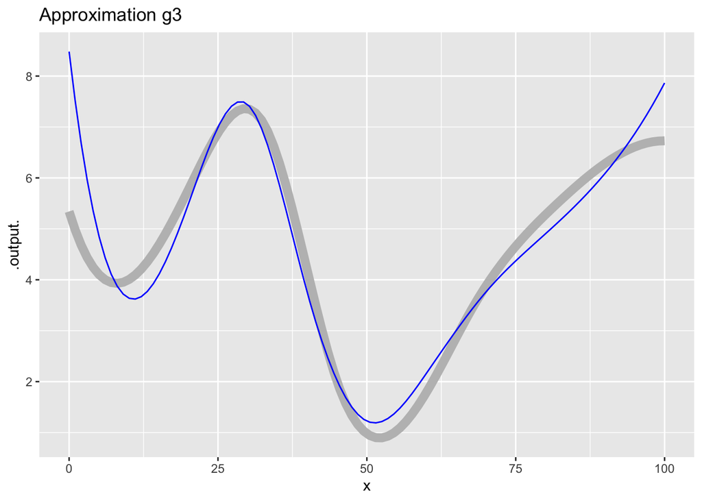

**Question tmp-1**: The function value

1. Good (+) []
2. OK [You might be looking at the large difference between the functions for $x < 5$. That’s reasonable. But focussing on the rest of the domain, the approximation is pretty good. ]
3. Horrible [You might be looking at the large difference between the functions for $x < 5$. That’s reasonable. But focussing on the rest of the domain, the approximation is pretty good. ]

**Question tmp-2**: The function’s derivative

1. Good [A reasonable answer, so long as you disregard the function over $x<20$.]
2. OK (+) []
3. Horrible [If you focus on the region $x < 20$ this is a good answer. And no instructions were given over how much of the domain the approximation needs to be good, ok, or horrible. The answer is a judgment call and your judgment is reasonable.]

**Question tmp-3**: The function’s second derivative

1. Good [Look at the region $70 < x < 100$. The sign of the 2nd-derivative of the approximation differs from that of the original function.]
2. OK [Look at the region $70 < x < 100$. The sign of the 2nd-derivative of the approximation differs from that of the original function.]
3. Horrible (+) []

**Question tmp-4**: The function’s integral from 10 to 90

1. Good (+) []
2. OK []
3. Horrible []